# Base R Visualization

36-350 – Statistical Computing

Week 5 – Fall 2020

# Caveat!

This set of notes is simply meant to point you to a few base `R` visualization functions such as `hist()` and `plot()`.

*It will not tell you* **when** *to use particular visualizers or* **what** *the output means*.

(For instance, we will not discuss when you’d use a histogram as opposed to a boxplot. That’s for other courses.)

# Example Data

Here we will load some data to visualize using functions from Notes 5A:

```r
require(readr)
file.url = url("http://www.stat.cmu.edu/~pfreeman/GalaxyStatistics.txt") # see "connections"
df = read_delim(file.url,delim=" +")
names(df)
```

```
## [1] "Field"         "Gini"          "Concentration"
```

```r
nrow(df)
```

```
## [1] 8358
```

(I generally use `df` to denote a data frame.) The data are two metrics of galaxy light concentration as measured for 8358 galaxies viewed in five different sky fields.)

# Univariate Visualization: Histogram

`hist(x,breaks=<value>,probability=<value>,…)`

- *x*: the variable to visualize
- *breaks*: if a single number, the number of bins; if a vector, the placement of the bin boundaries
- *probability*: if `FALSE` (default), a frequency histogram is generated; if `TRUE`, a pdf-like histogram is generated

Note: `hist()` features “invisible return”; if you say `hist(...)`, a histogram is plotted and nothing is printed in the console, while if you say `h = hist()`, a histogram is plotted and an `R` object containing information about the histrogram (break point placement, etc.) is assigned to the variable `h`.

# Univariate Visualization: Histogram

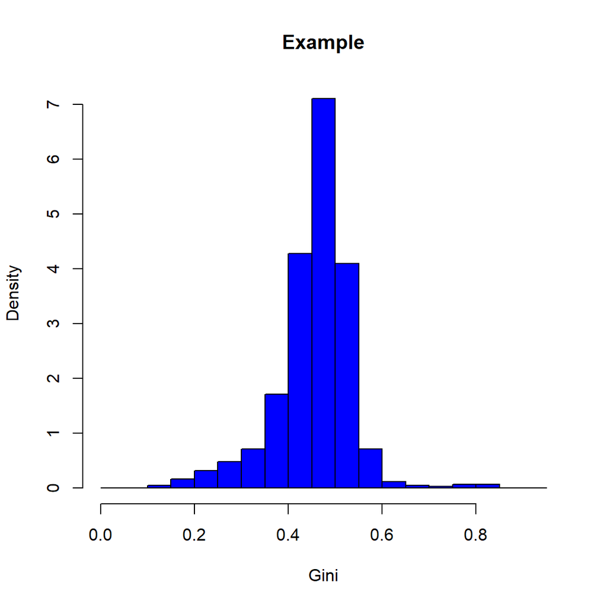

```r
h = hist(df$Gini,breaks=30,probability=TRUE,xlab="Gini",main="Example",col="blue")
```

```r
names(h)
```

```
## [1] "breaks"   "counts"   "density"  "mids"     "xname"    "equidist"
```

```r
h$counts
```

```
##  [1]    1    2   20   68  134  201  297  716 1791 2973 1713  298   50   22   11
## [16]   30   27    2    2
```

# Univariate Visualization: Boxplot

`boxplot(x,…)`

boxplot(formula,data=<value>,…)

- *x*: the variable to visualize
- *formula*: if creating side-by-side boxplots, the specification of how grouping is to be done
- *data*: the data frame in which the grouping variable exists

Note: like `hist()`, `boxplot()` features “invisible return”.

# Univariate Visualization: Boxplot

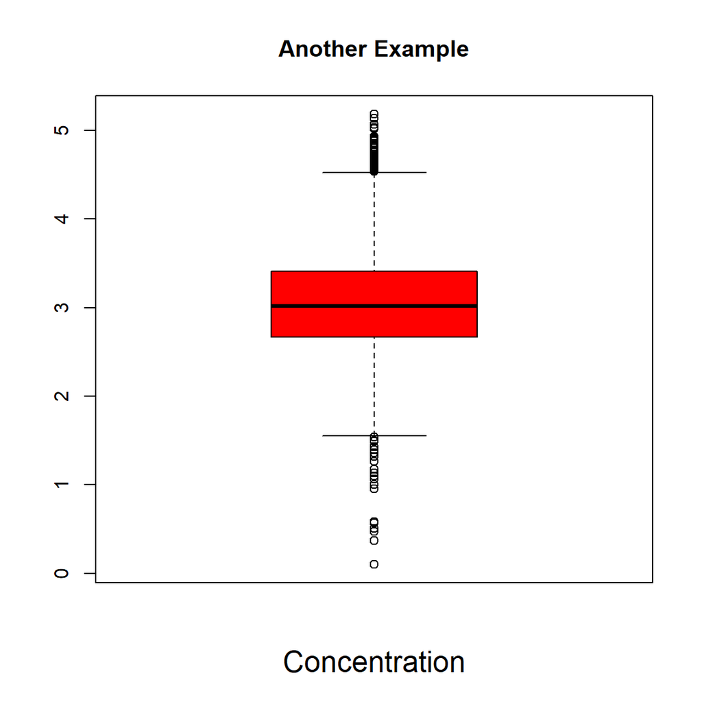

```r
boxplot(df$Concentration,xlab="Concentration",cex.lab=1.5,main="Another Example",col="red")
```

# Univariate Visualization: Boxplot

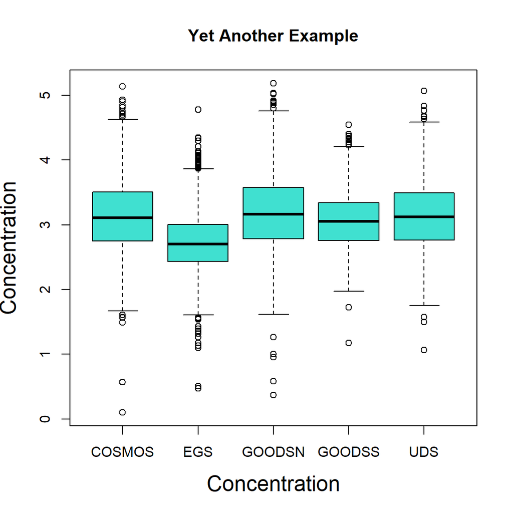

```r
boxplot(Concentration~Field,data=df,xlab="Concentration",cex.lab=1.5,main="Yet Another Example",
        col="turquoise")
```

The formula tells `boxplot()` to split the data frame using values of the factor variable `Field` and to compute boxplots of `Concentration` for each field. Hence the formula is essentially a shorthand for performing a split-apply-combine operation.

# Bivariate Visualization: Plot

`plot(x,y,…)`

- *x* and *y*: the variables to visualize

Note: `plot()` does *not* feature “invisible return”.

# Bivariate Visualization: Plot

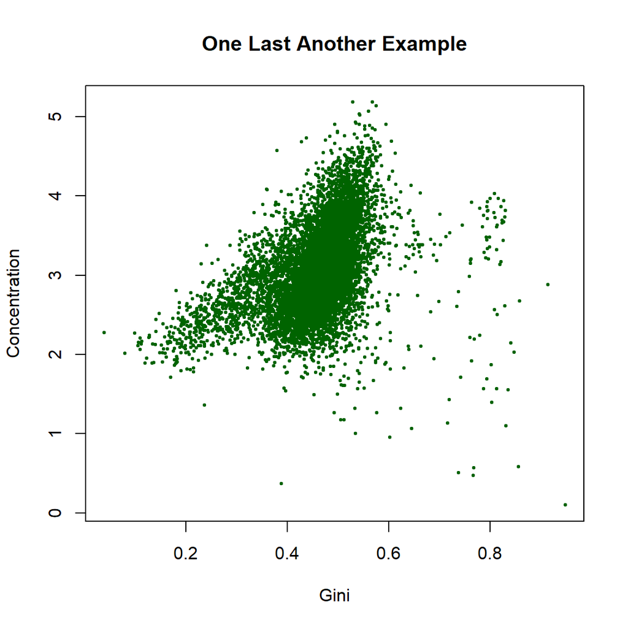

```r
plot(df$Gini,df$Concentration,xlab="Gini",ylab="Concentration",main="One Last Another Example",
     col="darkgreen",pch=19,cex=0.4)
```

[This website](http://www.stat.columbia.edu/~tzheng/files/Rcolor.pdf) shows you the full palette of colors in `R`. (`papayawhip`, yinz.)

[This other website](http://www.sthda.com/english/wiki/r-plot-pch-symbols-the-different-point-shapes-available-in-r) shows your plotting symbol options (`pch`).